# Titanic Kaggle

Maestro

2019/03/12

# 1 Introduction

인사이트 = 데이터의 분석 + 경험과 지식의 해석

인사이트의 두 가지 조건 중 첫 번째 조건을 충족하기 위해 캐글을 시작한다.

우선은 필사로 시작하며, 몇 번의 필사를 거친 후에 스스로 커널을 작성할 예정이다.

https://www.kaggle.com/redhorse93/r-titanic-data

이번 필사는 상기 커널이며, ’Competiton’중 ’Titanic’에 대한 분석 과정을 담은 것이다.

# 2 사전 준비

## 2.1 Package

```r
# Data input, assement: 데이터 로드, 확인
library(tidyverse)     # R의 통합 패키지로 여기서는 'readr'패키지를 쓰기 위함이다.
library(descr)         # descr::CrossTable() - 범주별 빈도수, 비율 수치로 확인

# Visualization
library(VIM)           #Missing values assement use by VIM::aggr()
#library(ggplot2)      #Used in almost visualzation 원문에선 따로 패키지를 부르지만,
                       #tidyverse내에 포함된 패키지로 여기선 주석으로 처리한다.
library(RColorBrewer)  # plot의 color 설정
library(scales)        # plot setting - x, y 축 설정

# Feature Engineering, Data Pre-processing
#library(tidyverse)    # 아래 패키지는 모두 포함하기에 주석 처리한다.
#library(dplyr)        # Feature Engineering & Data Pre-processing
#library(purrr)        # Check missing values
#library(tidyr)        # tidyr::gather()

# Model generation
library(randomForest)  # For Random Forest Modeling

# Model validation :   원문 커널에선 생략된 내용이다.
#library(caret)        # caret::confusionMatrix()
#library(ROCR)         # Plotting ROC Curve
```

### 2.1.1 multiplot() function generation

한 화면에 여러개 ‘plot’들을 표기하기 위해 ’multiplot()’ 함수를 사용한다.

하지만 원문의 필자는 어떤 문제가 생겨 ’multiplot()’함수를 사용할 수 없어,

’CRAN’을 참고하여 ’multiplot()’함수를 생성해서 사용했다.

```r
# Multiple plot function
#
# ggplot objects can be passed in ..., or to plotlist (as a list of ggplot objects)
# - cols:   Number of columns in layout
# - layout: A matrix specifying the layout. If present, 'cols' is ignored.
#
# If the layout is something like matrix(c(1,2,3,3), nrow=2, byrow=TRUE),
# then plot 1 will go in the upper left, 2 will go in the upper right, and
# 3 will go all the way across the bottom.
#

multiplot <- function(..., plotlist = NULL, file, cols = 1, layout = NULL) {
  library(grid)

  # Make a list from the... arguments and plotlist
  plots <- c(list(...), plotlist)

  numPlots = length(plots)

  # If layout is NULL< then use 'cols' to determine layout
  if (is.null(layout)) {
    # Make the panel
    # ncol: number of columns of plots
    # nrow: Number of rows needed, calculated from # of cols
    layout <- matrix(seq(1, cols * ceiling(numPlots/cols)),
                     ncol = cols, nrow = ceiling(numPlots/cols))
  }

  if (numPlots==1) {
    print(plots[[1]])

  } else {
    # Set up the page
    grid.newpage()
    pushViewport(viewport(layout = grid.layout(nrow(layout), ncol(layout))))

    # Make each plot, in the correct location
    for (i in 1:numPlots) {
      # Get the i, j matrix positions of the regions that contain this subplot
      matchidx <- as.data.frame(which(layout == i, arr.ind = TRUE))

      print(plots[[i]], vp = viewport(layout.pos.row = matchidx$row,
                                      layout.pos.col = matchidx$col))
    }
  }
 }
```

## 2.2 Raw data import : 데이터 원본 로드

‘Model’을 생성하는데 쓰는 ’train’ data와 실제 예측에 쓰는 ‘test’ data가 분리되어 있다.

2개 data를 로드한 후에 묶을 예정이다.

분리된 data를 묶는 이유는 모델링에 사용되는 입력 변수들을 Feature Engineering,

Pre-processing 할 때 동일하게 작업하기 위해서이다.

```r
train <- readr::read_csv("./input/train.csv")

test  <- readr::read_csv("./input/test.csv")

full  <- dplyr::bind_rows(train, test)
```

’read_csv()’가 ’read.csv’보다 로딩 속도가 조금 더 빠르기에 이 함수를 사용한다.

주의점은 문자열(‘Character’)와 요인 변수(‘Factor’)를 구별하지 않고 모두 ’Chr’로 저장된다.

데이터를 ’full’로 묶으면서 ’rbind()’대신 ’bind_rows()’를 쓴 이유는 ’test’에는

’Titanic competition’의 종속변수(타겟변수, Y)인 ’Survived’가 없어서 데이터의

차원(‘dimention’)이 맞지 않다. 그래서 ’rbind()’로는 병합되지 않기에 후자를 썻다.

’bind_rows()’는 ’test’의 ’Survived’를 ’NA’로 처리하면서 하나로 병합이 가능하다.

## 2.3 변수 의미 설명

각 변수의 의미와 지정한 속성은 아래 표와 같다.

| 변수명 | 해석(의미) | Type |
| --- | --- | --- |
| **PassengerID** | 승객을 구별하는 고유 ID number | Int |
| **Survived** | 승객의 생존 여부를 나타내며 생존은 1, 사망은 0 | Factor |
| **Pclass** | 선실의 등급으로서 1등급(1)부터 3등급(3)까지 3개 범주 | Ord.Factor |
| **Name** | 승객의 이름 | Factor |
| **Sex** | 승객의 성별 | Factor |
| **Age** | 승객의 나이 | Numeric |
| **SibSp** | 각 승객과 동반하는 형제 또는 배우자의 수를 설명하는 변수이며 0부터 8까지 존재 | Integer |
| **Parch** | 각 승객과 동반하는 부모님 또는 자녀의 수를 설명하는 변수이며 0부터 9까지 존재 | Integer |
| **Ticket** | 승객이 탑승한 티켓에 대한 문자열 변수 | Factor |
| **Fare** | 승객이 지금까지 여행하면서 지불한 금액에 대한 변수 | Numeric |
| **Cabin** | 각 승객의 선실을 구분하는 변수이며 범주와 결측치가 너무 많다. | Factor |
| **Embarked** | 승선항, 출항지를 나타내며 C, Q, S 3개 범주 | Factor |

표보다 더 상세한 정보는 나무위키의 타이타닉 관련 링크를 참조 바란다.

[링크](https://namu.wiki/w/RMS%20%ED%83%80%EC%9D%B4%ED%83%80%EB%8B%89)

```r
full <- full %>%
  dplyr::mutate(Survived = factor(Survived),
                Pclass = factor(Pclass, ordered = T),
                Name = factor(Name),
                Sex = factor(Sex),
                Ticket = factor(Ticket),
                Cabin = factor(Cabin),
                Embarked = factor(Embarked))
```

# 3 탐색적 데이터 분석(EDA : Exploratory Data Analysis)

결측치, 이상치 외 data 확인 작업 과정

여러 함수와 시각화를 사용하여 확인

## 3.1 수치값을 활용한 data 확인

’head()’와 ’summary()’로 data 확인

### 3.1.1 head()

```r
head(full, 10)
```

```
## # A tibble: 10 x 12
##    PassengerId Survived Pclass Name  Sex     Age SibSp Parch Ticket  Fare
##          <dbl> <fct>    <ord>  <fct> <fct> <dbl> <dbl> <dbl> <fct>  <dbl>
##  1           1 0        3      Brau~ male     22     1     0 A/5 2~  7.25
##  2           2 1        1      Cumi~ fema~    38     1     0 PC 17~ 71.3
##  3           3 1        3      Heik~ fema~    26     0     0 STON/~  7.92
##  4           4 1        1      Futr~ fema~    35     1     0 113803 53.1
##  5           5 0        3      Alle~ male     35     0     0 373450  8.05
##  6           6 0        3      Mora~ male     NA     0     0 330877  8.46
##  7           7 0        1      McCa~ male     54     0     0 17463  51.9
##  8           8 0        3      Pals~ male      2     3     1 349909 21.1
##  9           9 1        3      John~ fema~    27     0     2 347742 11.1
## 10          10 1        2      Nass~ fema~    14     1     0 237736 30.1
## # ... with 2 more variables: Cabin <fct>, Embarked <fct>
```

결과를 보면 ’Age’에 결측치가 있다.

’Age’외 다른 변수들엔 결측치가 없는지는 추후에 확인한다.

### 3.1.2 str()

```r
str(full)
```

```
## Classes 'spec_tbl_df', 'tbl_df', 'tbl' and 'data.frame': 1309 obs. of  12 variables:
##  $ PassengerId: num  1 2 3 4 5 6 7 8 9 10 ...
##  $ Survived   : Factor w/ 2 levels "0","1": 1 2 2 2 1 1 1 1 2 2 ...
##  $ Pclass     : Ord.factor w/ 3 levels "1"<"2"<"3": 3 1 3 1 3 3 1 3 3 2 ...
##  $ Name       : Factor w/ 1307 levels "Abbing, Mr. Anthony",..: 156 287 531 430 23 826 775 922 613 855 ...
##  $ Sex        : Factor w/ 2 levels "female","male": 2 1 1 1 2 2 2 2 1 1 ...
##  $ Age        : num  22 38 26 35 35 NA 54 2 27 14 ...
##  $ SibSp      : num  1 1 0 1 0 0 0 3 0 1 ...
##  $ Parch      : num  0 0 0 0 0 0 0 1 2 0 ...
##  $ Ticket     : Factor w/ 929 levels "110152","110413",..: 721 817 915 66 650 374 110 542 478 175 ...
##  $ Fare       : num  7.25 71.28 7.92 53.1 8.05 ...
##  $ Cabin      : Factor w/ 186 levels "A10","A11","A14",..: NA 107 NA 71 NA NA 164 NA NA NA ...
##  $ Embarked   : Factor w/ 3 levels "C","Q","S": 3 1 3 3 3 2 3 3 3 1 ...
```

data는 12열(변수) 1309행(관측치.train: 891, test: 418)이다.

그 외 각 변수의 속성과 ‘factor’ 속성의 변수들에 범주가 몇 개 인지도 확인 가능하다.

‘head()’ 결과 ‘Age’외 ’Cabin’ 에도 결측치가 있음을 알 수 있다.

### 3.1.3 summary()

```r
summary(full)
```

```
##   PassengerId   Survived   Pclass                                Name
##  Min.   :   1   0   :549   1:323   Connolly, Miss. Kate            :   2
##  1st Qu.: 328   1   :342   2:277   Kelly, Mr. James                :   2
##  Median : 655   NA's:418   3:709   Abbing, Mr. Anthony             :   1
##  Mean   : 655                      Abbott, Master. Eugene Joseph   :   1
##  3rd Qu.: 982                      Abbott, Mr. Rossmore Edward     :   1
##  Max.   :1309                      Abbott, Mrs. Stanton (Rosa Hunt):   1
##                                    (Other)                         :1301
##      Sex           Age            SibSp            Parch
##  female:466   Min.   : 0.17   Min.   :0.0000   Min.   :0.000
##  male  :843   1st Qu.:21.00   1st Qu.:0.0000   1st Qu.:0.000
##               Median :28.00   Median :0.0000   Median :0.000
##               Mean   :29.88   Mean   :0.4989   Mean   :0.385
##               3rd Qu.:39.00   3rd Qu.:1.0000   3rd Qu.:0.000
##               Max.   :80.00   Max.   :8.0000   Max.   :9.000
##               NA's   :263
##       Ticket          Fare                     Cabin      Embarked
##  CA. 2343:  11   Min.   :  0.000   C23 C25 C27    :   6   C   :270
##  1601    :   8   1st Qu.:  7.896   B57 B59 B63 B66:   5   Q   :123
##  CA 2144 :   8   Median : 14.454   G6             :   5   S   :914
##  3101295 :   7   Mean   : 33.295   B96 B98        :   4   NA's:  2
##  347077  :   7   3rd Qu.: 31.275   C22 C26        :   4
##  347082  :   7   Max.   :512.329   (Other)        : 271
##  (Other) :1261   NA's   :1         NA's           :1014
```

’summary()’는 많은 것을 알 수 있다.

수량형(Integer, Numeric) 변수들의 대표값, 범주형(Factor) 변수들의 범주 갯수,

범주별 관측치 갯수까지 확인이 가능하다.

아래 사항들은 변수에 대한 간략 설명이다.

1. `Survived` : 이번 `competition`의 타겟 변수이며 418개의 결측치는 Test data 때문이다.
2. `Pclass` : 1등급, 2등급, 3등급으로 범주가 세 개인데 3등급 승객이 가장 많다.
3. `Name` : 이름이 비슷한 사람들이 있다. 따라서 혼자 탄 승객도 있지만 가족들과 같이 탑승한 승객도 있음을 알 수 있다.
4. `Sex` : 남성이 여성보다 2배 가까이 더 많다.
5. `Age` : 0.17부터 80세까지 있는데 0.17을 잘못 기입한 이상치 인건지 확인이 필요해보이며, 263개의 결측치가 존재한다.
6. `SibSp` : 0부터 8까지 있는데 3분위수가 1이므로 부부 혹은 형제와 함께 Titanic호에 탑승했음을 알 수 있다.
7. `Parch` : 0부터 9까지 있지만 3분위수가 0인 것을 통해서 부모, 자녀들과 함께 탄 승객들이 거의 없음을 알 수 있다.

`SibSp`와 `Parch`는 모두 가족관계를 나타내는 변수들이다. 이를 활용하여 가족 중 누가 탔는지는 모르지만 동승한 인원이 총 몇 명인지 구하고, 그것을 바탕으로 가족의 규모를 나타내는 `FamilySized` 라는 범주형 파생변수도 만들 것이다.

8. `Ticket` : `3.1.2 str()`의 결과와 같이보면 완전히 동일한 티켓을 가진 승객들도 있고, 티켓이 일정 부분만 겹치는 승객들도 있고 아예 다른 티켓을 가진 승객이 있음을 알 수 있다. 이것을 이용해서 `ticket.size`라는 파생변수를 만들 것이다.
9. `Fare` : 0부터 512까지 있고 1개의 결측치가 있다. 3분위수가 31.275이지만 최댓값이 512라 갭이 너무 커서 확인해 봐야겠다.
10. `Cabin` : 총 12개 Feature들 중에서 가장 많은(1014개) 결측치를 갖고 있다. 배의 구역을 나타내는 변수인데 활용할 방법이 없다면 버려야 될 것 같다.
11. `Embarked` : 총 3개 범주로 구성이 되어있고 S가 가장 많으며 2개의 결측치가 있다.

데이터를 탐색하기 전에 ‘summary()’, ‘str()’ 같은 관측 함수들로 기본 정보를 확인하면 좋다.

## 3.2 Missing value

변수의 결측치 여부와 있을 시 얼마나 존재하는지 확인하는 과정.

‘dplyr’, ‘ggplot2’,‘VIM’ 패키지들로 수치를 확인 후 시각화로 나타낼 예정이다.

### 3.2.1 VIM packages

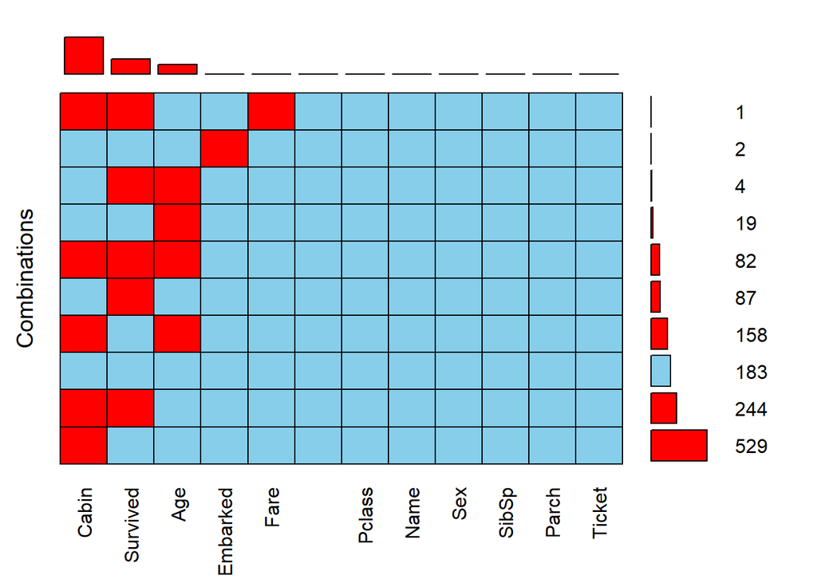

```
##
##  Variables sorted by number of missings:
##     Variable Count
##        Cabin  1014
##     Survived   418
##          Age   263
##     Embarked     2
##         Fare     1
##  PassengerId     0
##       Pclass     0
##         Name     0
##          Sex     0
##        SibSp     0
##        Parch     0
##       Ticket     0
```

```r
VIM::aggr(full, prop = FALSE, combined = TRUE, numbers = TRUE,
          sortVars = TRUE, sortCombs = TRUE)
```

### 3.2.2 tidyverse packages

‘VIM’ 패키지가 아닌, ’tidyverse’로도 결측치를 확인할 수 있다.

’dplyr’로 변수별 결측치 비율을 알아본다.

```r
full %>%
  dplyr::summarise_all(funs(sum(is.na(.))/n()))
```

```
## # A tibble: 1 x 12
##   PassengerId Survived Pclass  Name   Sex   Age SibSp Parch Ticket    Fare
##         <dbl>    <dbl>  <dbl> <dbl> <dbl> <dbl> <dbl> <dbl>  <dbl>   <dbl>
## 1           0    0.319      0     0     0 0.201     0     0      0 7.64e-4
## # ... with 2 more variables: Cabin <dbl>, Embarked <dbl>
```

확인 결과 ‘Age’,‘Cabin’외 ’Survived’, ‘Fare’,’Embarked’에도 결측치가 있음을 알 수 있다.

결측치는 비율로 확인하는 방법도 있지만, 시각화를 통해 확인할 수도 있다.

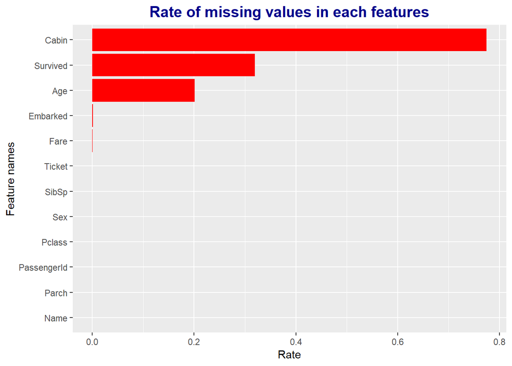

```r
# 각 feature의 결측치 비율 계산 -> Data Frame 속성 but 1행 12열 구조로 되어있다.
missing_values <- full %>%
  dplyr::summarise_all(funs(sum(is.na(.))/n()))

# 위에서 구한 missing_values를 12x2 data frame으로 생성
missing_values <- tidyr::gather(missing_values,
                                key = 'feature', value = 'missing_pct')

# missing_values를 활용한 시각화
missing_values %>%
  # Aesthetic setting: missing_pct 내림차순으로 정렬
  ggplot(aes(x = reorder(feature, missing_pct), y = missing_pct)) +
  # Bar plot
  geom_bar(stat = 'identity', fill = 'red') +
  # Title generation
  ggtitle('Rate of missing values in each features') +
  # Title detail setting
  theme(plot.title = element_text(face = 'bold',    #글씨체
                                  hjust = 0.5,       # Horizon(가로비율)
                                  size = 15,
                                  color = 'darkblue')) +
  # x, y axis label setting
  labs(x = 'Feature names', y = 'Rate') +
  # Plot의 x, y 축 변환
  coord_flip()
```

확인 결과 12개 변수중 총 5개에 결측치가 존재하며, ‘Cabin’,‘Age’,‘Embarked’,‘Fare’

순으로 결측치가 많음을 알 수 있다.(’Survived’는 test data결합시 생긴 값으로 제외)

시각화로 ’feature’를 분석, 탐색해 보자.

## 3.3 Age

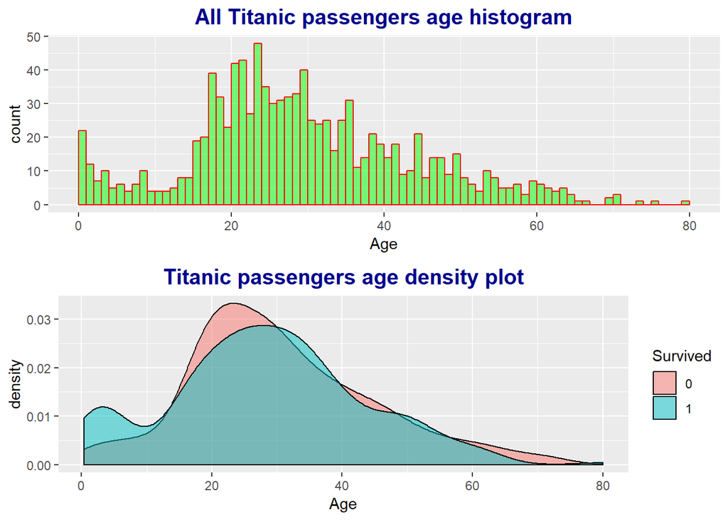

```r
age.p1 <- full %>%
  ggplot(aes(Age)) +
  # 히스토그램 작성, 설정
  geom_histogram(breaks = seq(0, 80, by = 1), #간격 설정
                 col = 'red',     # 막대 경계선 색깔
                 fill = 'green',  # 막대 채우기 색깔
                 alpha = .5) +     # 막대 투명도 50%
  # Plot title
  ggtitle('All Titanic passengers age histogram') +
  theme(plot.title = element_text(face = 'bold',   #글씨체
                                    hjust = 0.5,  #Horizon(가로비율)
                                    size = 15,
                                    color = 'darkblue'))

age.p2 <- full %>%
  # test data set의 Survived == NA 인 값들 제외
  filter(!is.na(Survived)) %>%
  ggplot(aes(Age, fill = Survived)) +
  geom_density(alpha = .5) +
  ggtitle('Titanic passengers age density plot') +
  theme(plot.title = element_text(face = 'bold', hjust = 0.5,
                                  size = 15, color = 'darkblue'))

  # multiplot layout 형식 지정
  multi.layout = matrix(c(1, 1, 2, 2), 2, 2, byrow = T)

  # 위에서 생성한 2개의 그래프를 한 화면에 축력
  multiplot(age.p1, age.p2, layout = multi.layout)
```

## 3.4 Pclass

각 ’Pclass’에 해당하는 탑승객의 빈도수 시각화.

‘dplyr’패키지 활용하여 ’Pclass’ 별로 그룹핑,

범주별 빈도수를 나타내는 ‘data frame’ 생성한 후 ’ggplot’으로 시각화

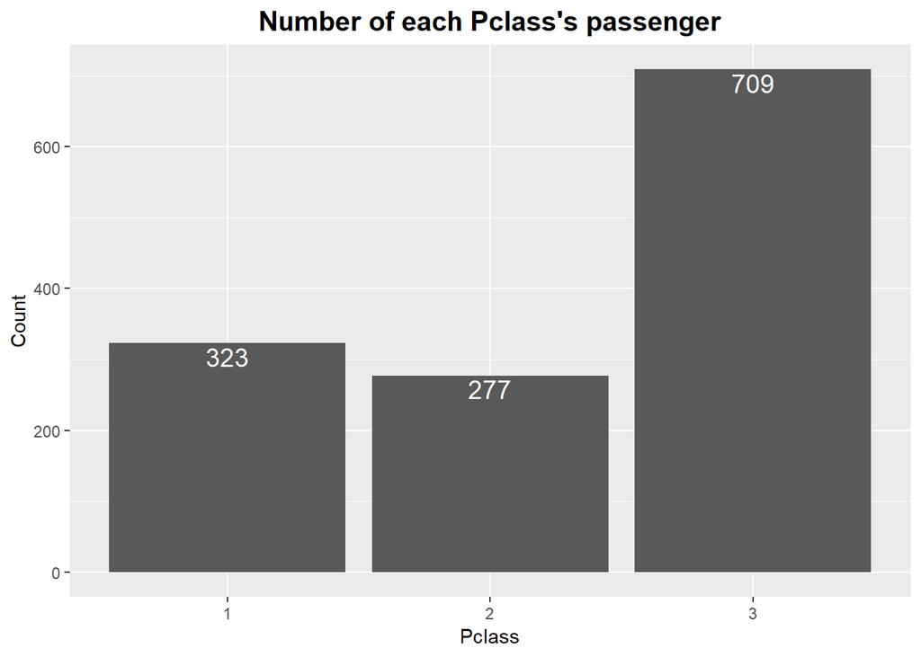

```r
full %>%
  # dplyr::group_by(), summarize() 를 이용해서 Pclass 빈도수 구하기
  group_by(Pclass) %>%
  summarize(N = n()) %>%
  # Aesthetic setting
  ggplot(aes(Pclass, N)) +
  geom_col() +
  # Pclass 빈도수 plot에 출력
  geom_text(aes(label = N),  #Plot의 y에 해당하는 N(빈도수) 매핑
            size = 5,   #글씨 크기
            vjust = 1.2,  #Vertical(가로) 위치 설정
            color = '#FFFFFF') +   #글씨 색깔 : 흰색
  # Plot title
  ggtitle("Number of each Pclass's passenger") +
  # Title setting
  theme(plot.title = element_text(face = 'bold', hjust = 0.5, size = 15)) +
  # x, y axis name change
  labs(x = 'Pclass', y = 'Count')
```

객실 등급과 생존율간의 연관성은 ’chapter5’에서 다룰 예정

## 3.5 Fare

티켓값 ‘Fare’ 시각화, histogram & boxplot으로 표현

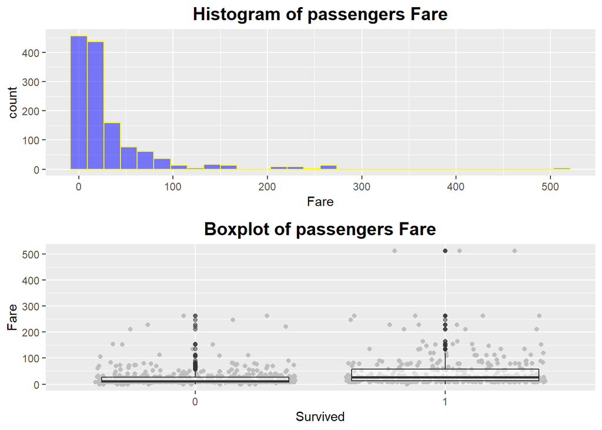

```r
  # Histogram
  Fare.p1 <- full %>%
    ggplot(aes(Fare)) +
    geom_histogram(col = 'yellow',
                   fill = 'blue',
                   alpha = .5) +
  ggtitle('Histogram of passengers Fare') +
  theme(plot.title = element_text(face = 'bold', hjust = 0.5, size = 15))

  # Boxplot
  Fare.p2 <- full %>%
    filter(!is.na(Survived)) %>%
    ggplot(aes(Survived, Fare)) +
    # 관측치는 회색점, 중복되는 부분은 흩뿌려서 나타냄
    geom_jitter(col='gray') +
    # boxplot : xnaudeh 50%
    geom_boxplot(alpha = .5) +
    ggtitle('Boxplot of passengers Fare') +
    theme(plot.title = element_text(face = 'bold', hjust = 0.5, size= 15))

  # multiplot layout 형식 지정
  mulit.layout = matrix(c(1, 1, 2, 2), 2, 2)

  # 위에서 생성한 2개 그래프를 한 화면에 출력
  multiplot(Fare.p1, Fare.p2, layout = multi.layout)
```

생존자들이 사망한 승객들보다 ’Fare’가 더 높지만 그렇게 큰 차이는 아님을 알 수 있다.

## 3.6 Sex

성별간 생존율 차이의 시각화

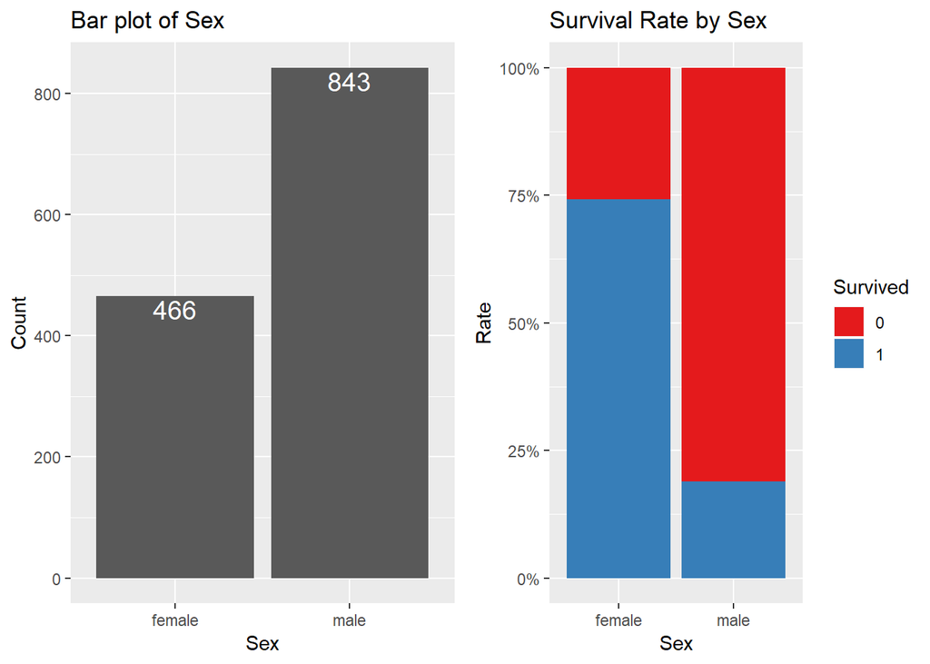

```r
sex.p1 <- full %>%
  dplyr::group_by(Sex) %>%
  summarize(N = n()) %>%
  ggplot(aes(Sex, N)) +
  geom_col() +
  geom_text(aes(label = N), size = 5, vjust = 1.2, color = "#FFFFFF") +
  ggtitle("Bar plot of Sex") +
  labs(x = "Sex", y = "Count")

sex.p2 <- full[1:891, ] %>% # 892행 이후부터는 'test' data로 생존율이 NA값임.
  ggplot(aes(Sex, fill = Survived)) +
  geom_bar(position = 'fill') +
  scale_fill_brewer(palette = "Set1") +
  scale_y_continuous(labels = percent) +
  ggtitle('Survival Rate by Sex') +
  labs(x = 'Sex', y = 'Rate')

multi.layout = matrix(rep(c(1, 2), times = 2), 2, 2, byrow = T)

multiplot(sex.p1, sex.p2, layout = multi.layout)
```

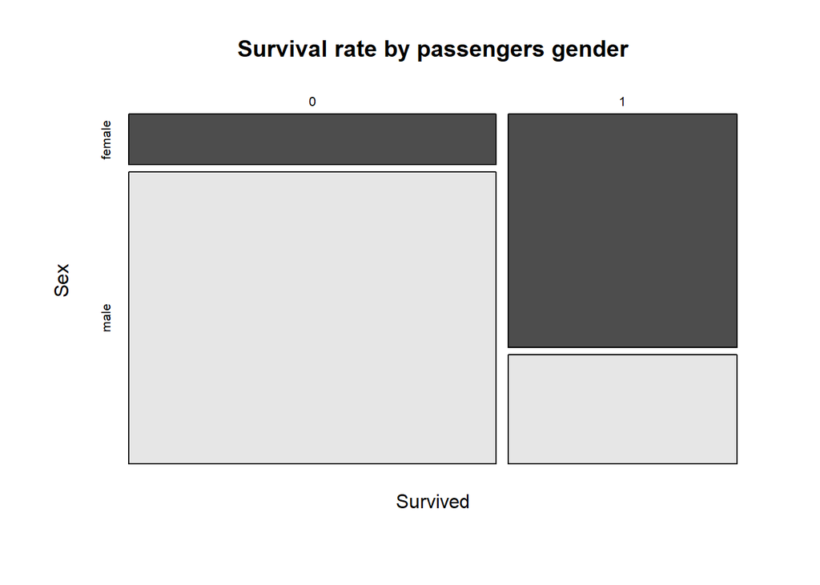

```r
mosaicplot(Survived ~ Sex,
           data = full[1:891, ], col = TRUE,
           main = 'Survival rate by passengers gender')
```

그래프를 보면, 인원은 남성이 더 많지만, 생존율은 여성이 더 높음을 알 수 있다.